# Out Of Box Demo User Guide

# Overview of MMWAVE SDK Out Of Box Demo

This is the mmWave SDK out-of-box demo lab for the TI mmWave EVM’s. Run this Out-Of-Box Demo to view processed TI mmWave sensor data in configurable plots using the web-based mmWave Demo Visualizer.

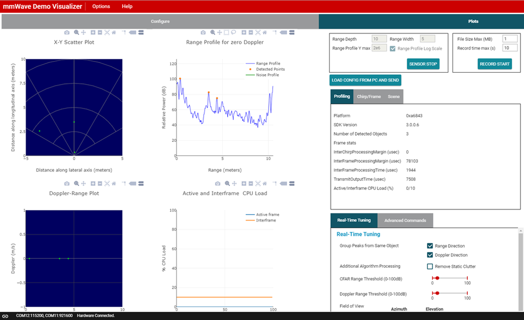

## EVM Compatibility

This demo supports most current mmWave EVM’s available currently. Below are the currently supported devices

[output not shown]

# Quickstart xWR68xx, xWR64xx, xWR18xx, xWR16xx and xWR14xx devices

## Requirements

| Tool | Version | Download Link |
| --- | --- | --- |
| Uniflash | Latest | [Downlad Uniflash](https://www.ti.com/tool/UNIFLASH) [Access Uniflash through the Cloud](https://dev.ti.com/uniflash/#!/) |
| Silicon Labs CP210x USB to UART Bridge VCP Drivers (only required in standalone mode) | Latest | [Latest SiLabs Driver](https://www.silabs.com/products/development-tools/software/usb-to-uart-bridge-vcp-drivers) |

## 1. Configure the EVM for Flashing Mode

Follow the steps in the EVM Setup Guide for your specific EVM.

## 2. Flash the EVM using Uniflash

Flash the appropriiate binary from the prebuilt binaries folder using UniFlash. Follow the instructions for using UniFlash Prebuilt binaries can be found in the following directory: `toolbox_install_Dir\source\ti\Out_Of_Box_Demo\prebuilt_binaries\`

## 3. Configure the EVM for Functional Mode

Follow the steps in the EVM Setup Guide for your specific EVM.

## 4. Open the mmWave Demo Visualizer

In google chrome, open the [mmWave Demo Visualizer](https://dev.ti.com/mmWaveDemoVisualizer) If prompted, follow the on-screen instructions for installing TI Cloud Agent

The mmWave Industrial visualizer is also compatible with the Out Of Box Demo. It is a python gui which can be used locally. It can be found under `{Toolbox_install_dir}/tools/Visualizer/`

## 5. Connect the Visualizer to the Device

In the GUI menu, select Options → Serial Port

- In the serial port window, enter the appropriate port in each of the drop down menus based on your port numbers from Uniflash section
- Click on Configure to connect the GUI to the EVM. The GUI Status bar should show **Conected:**

## 6. Running the Demo

- On the Configure Tab, select the appropriate mmWave SDK and the **xWR68XX device** from the Platform dropdown menu
- Use the available sliders to create the desired configuration.
  - You can also use the presets available in the Desirable Configuration drop-down list.
  - Additional details about the configuration parameters can be found in the [mmWave Demo Visualizer User Guide](http://www.ti.com/lit/pdf/swru529)

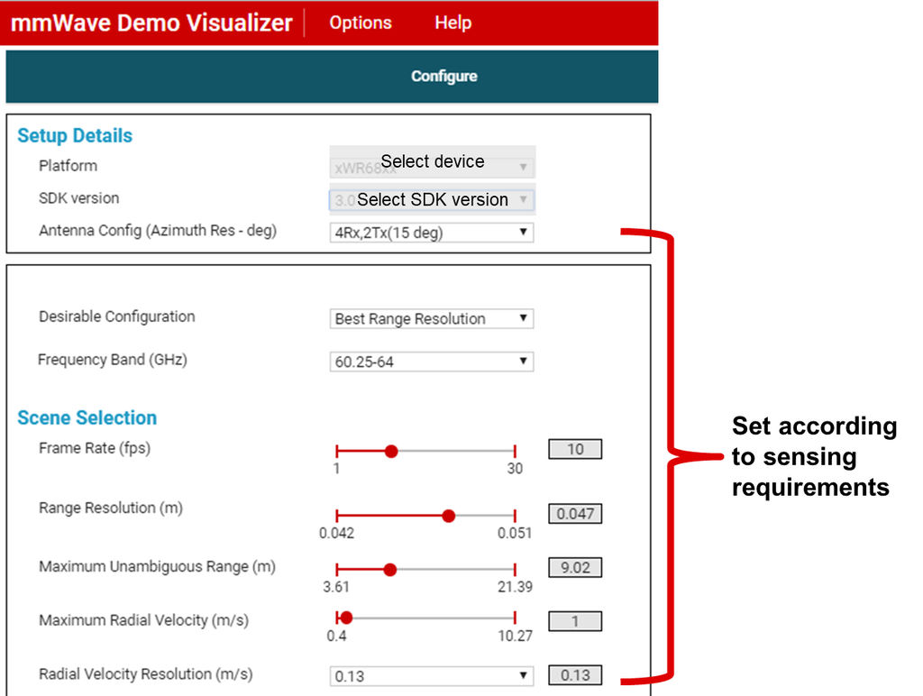

- Select the desired plots under Plot Selection (e.g. Scatter Plot, Range Azimuth Plot)
- When ready to send the configuration, click on Send Config To mmWave Device

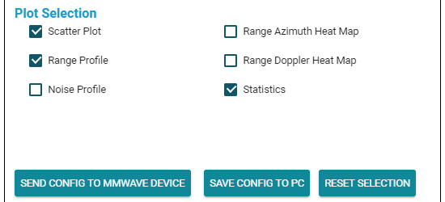

- Click on the Plots tab to view the plots that were selected to be shown

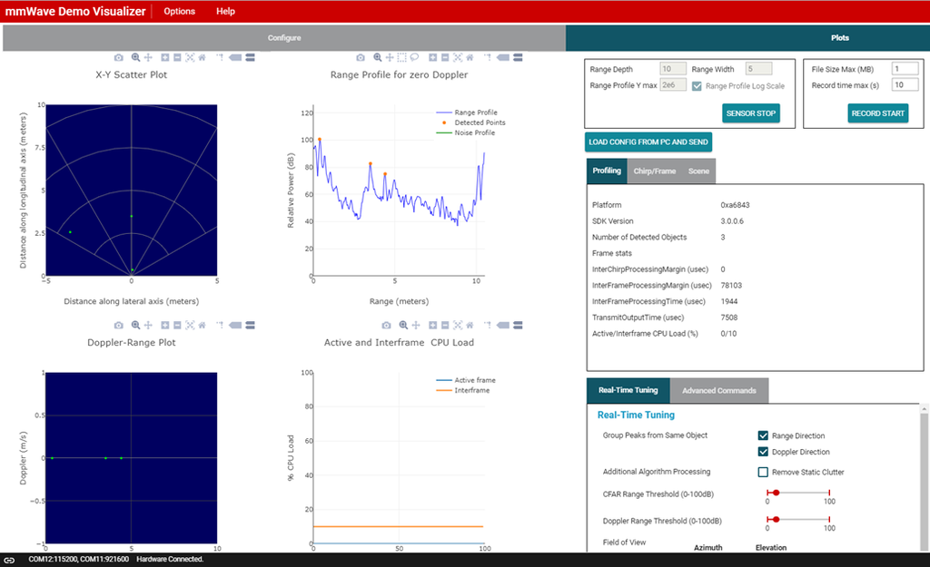

- Move a highly reflective object in front of the EVM and see how the demo responds.
  - You can use the Real Time Tuning controls shown below to adjust CFAR thresholds, Modify Field of View and enable or disable Peak grouping in real time.

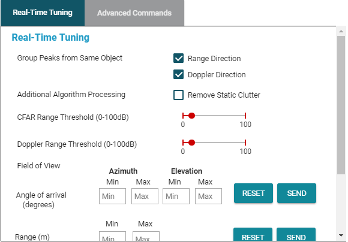

# Quickstart xWRL64xx device

## Requirements

| Tool | Version | Download Link |
| --- | --- | --- |
| Uniflash | Latest | [Downlad Uniflash](https://www.ti.com/tool/UNIFLASH) [Access Uniflash through the Cloud](https://dev.ti.com/uniflash/#!/) |
| Silicon Labs CP210x USB to UART Bridge VCP Drivers (only required in standalone mode) | Latest | [Latest SiLabs Driver](https://www.silabs.com/products/development-tools/software/usb-to-uart-bridge-vcp-drivers) |
| SDK | Latest | [SDK 5.x.x.x](https://www.ti.com/tool/MMWAVE-L-SDK) |

## 1. Configure the EVM for Flashing Mode

Follow the steps in the EVM Setup Guide for your specific EVM.

## 2. Open the Low Power Radar Visualizer

Navigate to the SDK download location and find the Low Power Radar Visualizer at `<MMWAVE_SDK_INSTALL_DIR>\tools\visualizer\sdk5_visualizer.exe`

## 3. Flash the EVM using Uniflash

1. Select the device in the drop down
2. Select the COM Port
3. Select baud rate
4. Upload release application image which can be found at `<MMWAVE_SDK_INSTALL_DIR>\examples\mmw_demo\presence_motion_detect\prebuilt_binaries` or `toolbox_install_Dir\source\ti\Out_Of_Box_Demo\prebuilt_binaries\`
5. Select the “FLASH” button

[figure not shown]

## 4. Configure the EVM for Functional Mode

Pop up will appear to prompt you to switch to functional mode and reset the device. Follow the steps in the visualizer also documented in the EVM Setup Guide for your specific EVM. RESET_SW button can be found to the left of the 5V power source and three LEDs.

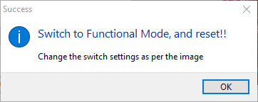

## 5. Send device configuration

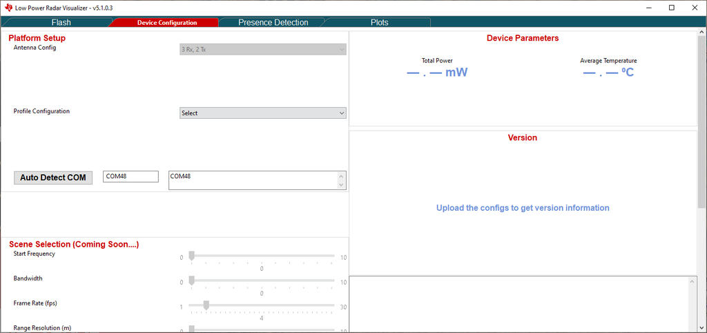

In Profile Configuration drop down select “Major motion” or “Minor motion”  
Select button “Send Configs to Device”  
In console window on the right of the screen the commands should appear being sent to the device

## 6. View presence detection

Once commands are sent the Presence Detection tab will open. Checkboxes on the right allow control of the visualization.

## 7. View plots

Open the plots tab to see more views of the radar data. Use the checkboxes on the right to control which plots are displayed.

[figure not shown]

# Developer’s Guide

## EVM Compatibility

This demo supports most current mmWave EVM’s available currently. Below are the currently supported devices

[output not shown]

> 📝 *NOTE*  
> **xWRL6432 CCS Support**  
> Please see SDK 5.1.0.3 documentation for CCS debug instructions with xWRL6432. If you have any questions reach out on our [e2e forums](https://www.e2e.ti.com).

## Build the Firmware from Source Code

### 1. Software Requirements

| Tool | Version | Download Link |
| --- | --- | --- |
| TI mmWave SDK | 3.6.0.0-LTS (6843, 6443, 1843, and 1642) 4.3.0.1 (AWR294x) 2.1.x.x (1443) | [mmWave SDK 3.6](https://www.ti.com/tool/MMWAVE-SDK) [mmWave SDK 4.3](https://www.ti.com/tool/MMWAVE-MCUPLUS-SDK) [Previous Versions](https://www.ti.com/tool/download/MMWAVE-SDK#previous-versions) |
| Code Composer Studio | Latest | [Code Composer Studio](https://www.ti.com/tool/CCSTUDIO) |
| Silicon Labs CP210x USB to UART Bridge VCP Drivers (only required in standalone mode) | Latest | [Latest SiLabs Driver](https://www.silabs.com/products/development-tools/software/usb-to-uart-bridge-vcp-drivers) |

### 2. Import Lab Project

The mmWave SDK Out-of-box demo Lab CCS Project is available on TI Resource Explorer under mmWave Sensors → Radar Toolbox. You can import the project in your CCS workspace using TI Resource Explorer in CCS or by importing the projectspec from a local copy of the toolbox. Both methods of importing projects are defined below. To get started, open CCS and set up your workspace as desired.

**Importing via TI Resource Explorer in CCS**

- In the top toolbar, navigate to **View → Resource Explorer**
- In the **Resource Explorer** side panel (not the main panel with “Welcome to..”), navigate to **Software → mmWave Sensors → Radar Toolbox - <ver> → Labs →**
- Select the Out Of Box Demo, and then choose the appropriate project for your specific device or EVM
- Click on the project, which should open the project in the right main panel, and then click on the Import to IDE button

.

**Importing via CCS Import Projectspecs**

- In the top toolbar, navigate to **Project → Import CCS Projects…**
- With the **Select search-directory** option enabled, click **Browse…**, navigate to the **Out_Of_Box_Demo** folder at `<toolbox_install_dir>\source\ti\examples\Out_Of_Box_Demo\` and then click **OK**.
- Under **Discovered projects**, select the appropriate project for your device or EVM then click **Finish**.

> 📝 *NOTE*  
> **Project Workspace**  
> When importing projects to a workspace, a copy is created in the workspace. It is important to note that the copy in user’s workspace is the one that gets built and all modifications will only be implemented for the workspace copy. The original project downloaded in the Radar Toolbox is not modified.

### 3. Build the Lab

#### **Build DSS Project**

If the applicable demo for your device utilizes the DSP, then it will contain a DSS project as well as an MSS project the DSS project must be built before the MSS project.

With the DSS project selected in **Project Explorer**, right click on the project and select **Rebuild Project**. Selecting **Rebuild** instead of **Build** ensures that the project is always re-compiled. This is especially important in case the previous build failed with errors.

Ensure that the DSS project builds without errors, which will be shown in the console window.

#### **Build MSS Project**

Select the MSS project in **Project Explorer**, right click on the project and select **Rebuild Project**.

> 🛑 *Before Continuing!*  
> **Build Fails with Errors**  
> If the build fails with errors, please ensure that all the prerequisites are installed as mentioned in the previous steps.

### 4. Execute the Lab

There are two ways to execute the compiled code on the EVM:

- **Deployment mode**: In this mode, the EVM boots autonomously from flash and starts running the bin image
  - Using Uniflash, flash the **.bin** file from the MSS project (typically in the **Debug** folder, but the folder name will depend on the project’s configuration)
  - The procedure to flash the EVM is the same as detailed in the Flash the EVM section.
- **Debug mode**: This mode is is used for downloading and running the executable (.xer4f and .xe674) from CCS. This mode enables JTAG connection with CCS while lab is running; useful during development and debugging.

## CCS Debug Mode

Follow the instructions for Using CCS Debug for Development

## Output from mmWave Demo Visualizer and Output using DCA1000EVM

The mmWave Demo Visualizer is used to visualize processed output data from the mmWave radar device. This processed output data can be saved in binary form to a .DAT file. Additionally, raw ADC data can be saved for offline processing using the [DCA1000 EVM](https://www.ti.com/tool/DCA1000EVM). To learn more about the structure of this output data please refer to the following resources:

> 📝 *NOTE*  
> **Output Data versus Raw ADC Data**  
> Output data refers to point cloud data (x,y,z,v). Raw ADC data refers to digitally sampled sensor data.
- Output Data Structure Information:
- `<MMWAVE_SDK_INSTALL_DIR>\packages\ti\demo\xwr68xx\mmw\docs\doxygen\html\index.html`
- How to use the [DCA100EVM](https://www.ti.com/tool/DCA1000EVM) for raw data capture:
- `<MMWAVE_SDK_INSTALL_DIR>\docs\mmwave_sdk_user_guide.pdf`  
  Section 3.3.2 mmWave Demo with LVDS-Based Instrumentation
- Parsing Script Information for mmWave Demo Visualizer
- `<MMWAVE_SDK_INSTALL_DIR>\docs\mmwave_sdk_user_guide.pdf`  
  Section 3.3.1 mmWave Demo - Advanced GUI Options
- Parsing Script Location for mmWave Demo Visualizer and [DCA100EVM](https://www.ti.com/tool/DCA1000EVM) for raw data capture:
- `<MMWAVE_SDK_INSTALL_DIR>\packages\ti\demo\parser_scripts`

# Need More Help?

- Additional resources in the documentation of the mmWave SDK (note hyperlinks will only work if the mmWave SDK has been installed on PC):
  - [mmWave SDK User’s Guide located at `<mmwave_sdk_install_dir>/docs/mmwave_sdk_user_guide.pdf`](http://software-dl.ti.com/ra-processors/esd/MMWAVE-SDK/latest/exports/mmwave_sdk_user_guide.pdf)
  - [mmWave SDK Release Notes located at `<mmwave_sdk_install_dir>/docs/mmwave_sdk_release_notes.pdf`](http://software-dl.ti.com/ra-processors/esd/MMWAVE-SDK/latest/exports/mmwave_sdk_release_notes.pdf)
- Search for your issue or post a new question on the [mmWave E2E forum](https://e2e.ti.com/support/sensor/mmwave_sensors/f/1023)